# Communicating Data Findings for PISA 2012 data set

## by Oleksandra Laurent

## Investigation Overview

In this investigation I was interested to look at the different aspects of students' life and how scores in all subjects are influenced by these aspects. The main features of interest in the data set were scores in math, science, reading and their average score and what those scores depend on. For this analysis I explored the features depending on:

- student personal trades like perseverance, coming to school on time, sense of belonging at school;
- family: which possessions student have at home, what is the parents' opinion of the importance of subjects;
- and schools: class size, teachers' support during lessons.

## Dataset Overview

The data consists of features of about 500000 students. This data is based on the PISA 2012 survey which consisted of a paper-based test taken by students, questionnaires taken by school principals to provide information about the students' backgrounds, schools and learning experiences and the broader school system and learning environment. All this information was gathered in the data set used in this analysis. There are 485490 students questioned with 17 selected features. Most of the variables are categorical. Some like scores and the size of the class are numeric features.

## Number of assessed students per country and gender distribution in data set

In the data this data set we had entries from more than 60 countries with different amount of participants from different countries. The highest amount of student's replies in data came from Mexico, Italy and Spain. Least - came from Liechtenstein. Most of the countries had assessed around 5000 - 7000 students. There were even amount of male and female students assessed which provided this analysis even gender distribution.

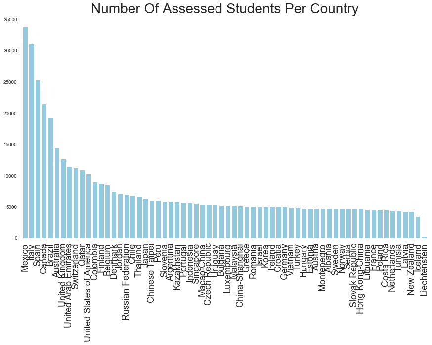

```python
plt.figure(figsize=[14.70, 8.27])
sns.set(style='white')
sns.countplot(data=df_clean, x = 'country',color='skyblue', order=df_clean['country'].value_counts().index);
sns.despine(bottom = True, left = True)
plt.xlabel(None )
plt.xticks( rotation=90, fontsize='18')
plt.ylabel(None)
plt.yticks( fontsize='10')
plt.title('Number of assessed students per country'.title(), fontsize=28)
plt.show()
```

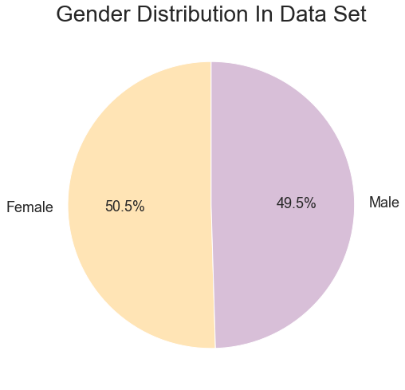

```python
colors=['moccasin', 'thistle']
df_clean.gender.value_counts().plot(kind = 'pie', autopct='%.1f%%', figsize=[14.70, 8.27], fontsize=18, startangle=90, colors=colors );
plt.title('Gender Distribution in Data Set'.title(), fontsize = 28) ;
plt.ylabel(None);
```

## Distribution of scores for each of the subjects

The distributions for all scores appeared to be uni-modal:

- with the distribution of math scores slightly right-skewed and reading score distribution slightly left-skewed.
- for all subjects most of the students received scores between 400-550 with slightly higher average scores for science.
- small groups of students received low scores between 100-300 and high scores between 650-800 in all subjects.

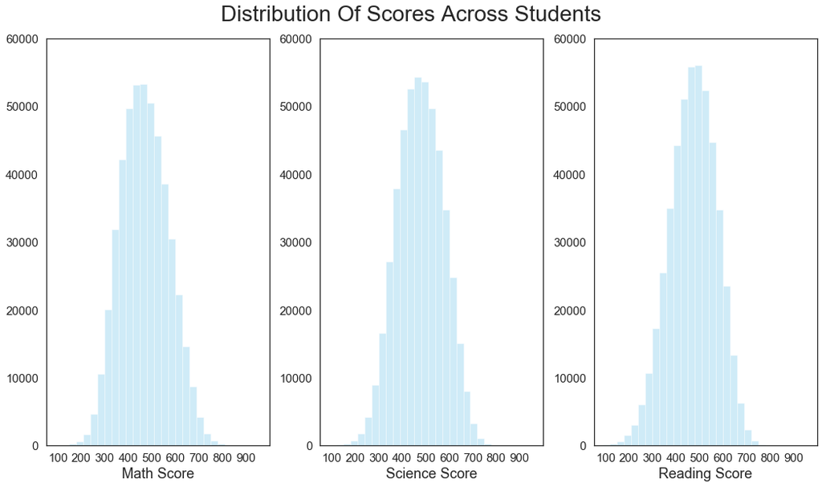

```python
fig, ax = plt.subplots( figsize = [14.70, 8.27])

#histogram of math score distribution
plt.subplot(1, 3, 1)
bin_edges = np.arange(0, df_clean['math_score'].max()+1, 30)
sns.distplot(df_clean['math_score'],  kde = False, bins = bin_edges, color='skyblue' );
# plot formatting
plt.xlabel('Math Score'.title(), fontsize=18)
plt.ylim(0, 60000)
plt.xlim(50, 1000)
plt.xticks([100,200,300,400,500,600,700,800,900], fontsize=15)
plt.yticks(fontsize=15)

#histogram of science score distribution
plt.subplot(1, 3, 2)
bin_edges = np.arange(0, df_clean['science_score'].max()+1, 30)
sns.distplot(df_clean['science_score'], kde = False, bins = bin_edges, color='skyblue');
# plot formatting
plt.xlabel('Science Score'.title(), fontsize=18)
plt.ylabel(None)
plt.ylim(0, 60000)
plt.xlim(50, 1000)
plt.xticks([100,200,300,400,500,600,700,800,900], fontsize=15)
plt.yticks(fontsize=15)

#histogram of reading score distribution
plt.subplot(1, 3, 3)
bin_edges = np.arange(0, df_clean['science_score'].max()+1, 30)
sns.distplot(df_clean['reading_score'], kde = False, bins = bin_edges, color='skyblue');
# plot formatting
plt.xlabel('Reading Score'.title(), fontsize=18)
plt.ylabel(None)
plt.ylim(0, 60000)
plt.xlim(50, 1000)
plt.xticks([100,200,300,400,500,600,700,800,900], fontsize=15)
plt.yticks(fontsize=15)

# set the overall title
plt.suptitle('Distribution of scores across students'.title(), fontsize=28, y=1.04)
plt.tight_layout();
plt.show()
```

## Top 10 performing countries for each subject

Through 3 subjects list of countries with the highest average score is very similar. In all 3 plots the highest average by **Shanghai(China)** followed by **Singapore** and **Hong Kong (China)** in math and vice versa for science and reading.

Korea, Liechtenstein, Japan, Estonia are presented among Top 10 for all subjects. Chinese Taipei is in Top 10 for scores in math and reading. Poland is in Top 10 for scores in science and reading.Macao(China) and Switzerland have 1 entrance in math Top 10. Vietnam and Finland are in Top 10 performing countries for the score in science. Ireland is presented in Top 10 in the reading score.

From 3 plots above it is clear that countries located in East Asia have the highest average scores through all subjects. Another region with high averages is Northern Europe with Estonia and Finland presented in plots.

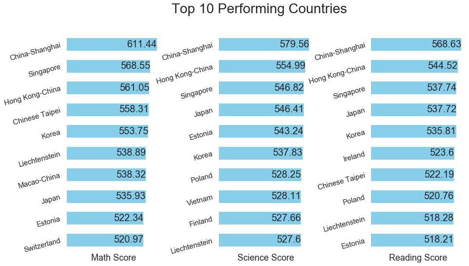

```python
#create average score in each subject by country
top_math=df_clean.groupby('country')['math_score'].mean().nlargest(10)
top_science=df_clean.groupby('country')['science_score'].mean().nlargest(10)
top_reading=df_clean.groupby('country')['reading_score'].mean().nlargest(10)

fig, ax = plt.subplots(figsize = [14.70, 8.27])
plt.subplots_adjust(wspace = 0.6)

#for math
plt.subplot(1, 3, 1)
top_math.plot( y='country', kind = 'barh', color='skyblue', width = 0.6)
plt.gca().invert_yaxis()
sns.despine(bottom = True, left = True)
plt.xlabel('Math Score'.title(), fontsize=18)
plt.ylabel(None)
plt.xticks(None)
plt.xticks([])
plt.yticks(fontsize=15, rotation=15)

for index, value in enumerate(top_math):
    plt.text( value, index, str(round(value, 2)), va = 'center', ha='right', fontsize=20)

#for science
plt.subplot(1, 3, 2)
top_science.plot( y='country', kind = 'barh', color='skyblue', width = 0.6)
plt.gca().invert_yaxis()
sns.despine(bottom = True, left = True)
plt.xlabel('Science Score'.title(), fontsize=18)
plt.ylabel(None)
plt.xticks([])
plt.yticks(fontsize=15, rotation=15)
for index, value in enumerate(top_science):
    plt.text( value, index, str(round(value, 2)), va = 'center', ha='right',fontsize=20)

#for reading
plt.subplot(1, 3, 3)
top_reading.plot( y='country', kind = 'barh', color='skyblue', width = 0.6)
plt.gca().invert_yaxis()
sns.despine(bottom = True, left = True)
plt.xlabel('Reading Score'.title(), fontsize=18)
plt.ylabel(None)
plt.xticks([])
plt.yticks(fontsize=15, rotation=15)
for index, value in enumerate(top_reading):
    plt.text( value, index, str(round(value, 2)), va = 'center', ha='right',fontsize=20)

# set the overall title
plt.suptitle('Top 10 performing countries'.title(), fontsize=28)
plt.show()
```

### Subjects score distributions by gender

Distribution was similar for all subjects. For scores in math male students had a slightly higher average than the females with the similar lower adjacent values and slightly higher upper adjacent values and with outlier higher on a scale. For scores in science, averages are the same for both genders, though distribution for the male is more spreader with outliers higher on a scale. For scores in reading average score of female students is higher than for males with lower adjacent values higher on a scale.

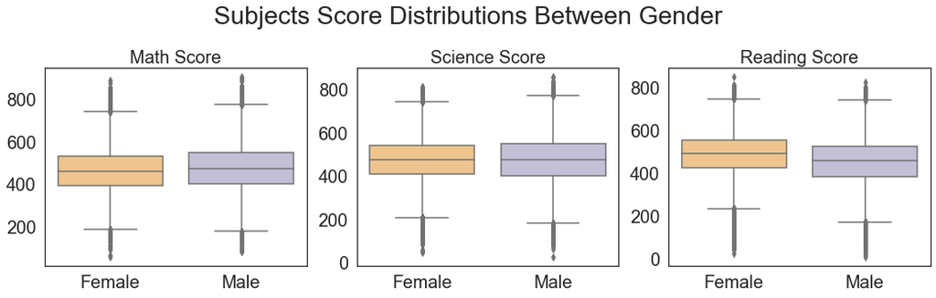

```python
fig, ax = plt.subplots(figsize = [14.70, 4.13])

#gender distribution for math score
plt.subplot(1, 3, 1)
sns.boxplot( y='math_score', x='gender', data=df_clean, palette = 'PuOr')
plt.xlabel(None)
plt.ylabel(None)
plt.title('Math Score'.title(), fontsize='20')
plt.xticks(fontsize=20)
plt.yticks(fontsize=20)

#gender distribution for science score
plt.subplot(1, 3, 2)
sns.boxplot(y='science_score', x='gender', data=df_clean, palette = 'PuOr')
plt.xlabel(None)
plt.ylabel(None)
plt.title('Science Score'.title(), fontsize='20')
plt.xticks(fontsize=20)
plt.yticks(fontsize=20)

#gender distribution for reading score
plt.subplot(1, 3, 3)
sns.boxplot(y='reading_score', x='gender', data=df_clean, palette = 'PuOr')
plt.xlabel(None)
plt.ylabel(None)
plt.title('Reading Score'.title(), fontsize='20');
plt.xticks(fontsize=20)
plt.yticks(fontsize=20);

plt.suptitle('Subjects score distributions between gender'.title(), fontsize=28, y=1.12);
plt.tight_layout();
```

### Math score vs Science score vs Reading score vs Gender

There were found a strong and positive correlation between any pair of the three subjects for each gender.

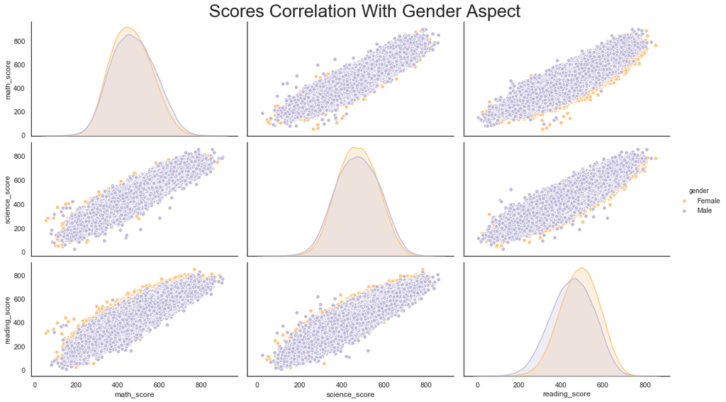

```python
g = sns.pairplot(data=df_clean, vars = ['math_score', 'science_score', 'reading_score'], hue='gender', palette='PuOr',
                height = 8.27/3,  aspect = (14.70/3)/(8.27/3))
plt.suptitle('Scores correlation with gender aspect'.title(), y = 1.04, fontsize=28);
```